# Lab 8 - Linear Regression in R

Tyanna Bui

11/22/2018

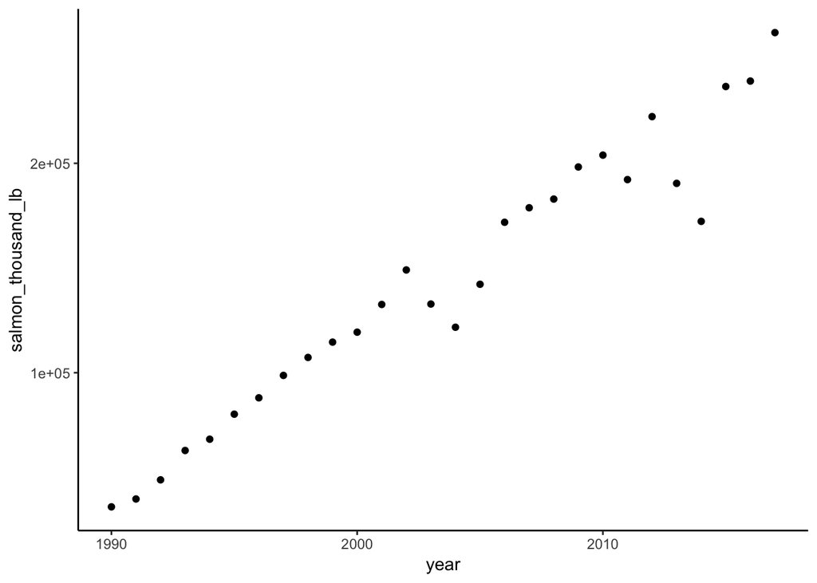

```
##
## Call:
## lm(formula = salmon_thousand_lb ~ year, data = salmon)
##
## Coefficients:
## (Intercept)         year
##   -14982940         7550
```

What does the *slope* mean in the context of this model?

The slope means that the amount of imported salmon there are has an increasting rate of 7.550e+03 salmon (1000 lbs)/year.

What does the *y-intercept* mean in the context of this model? Why is that concerning? What does this mean about *extrapolating* this model for past values?

The y-intercept means that if the year were to be zero, then the amount of imported salmon would be -1.498e+07 thousand lbs, and is concerning because it solely does not make sense since there are other factors that can affect this, thus the importance of extapolating this dataset.

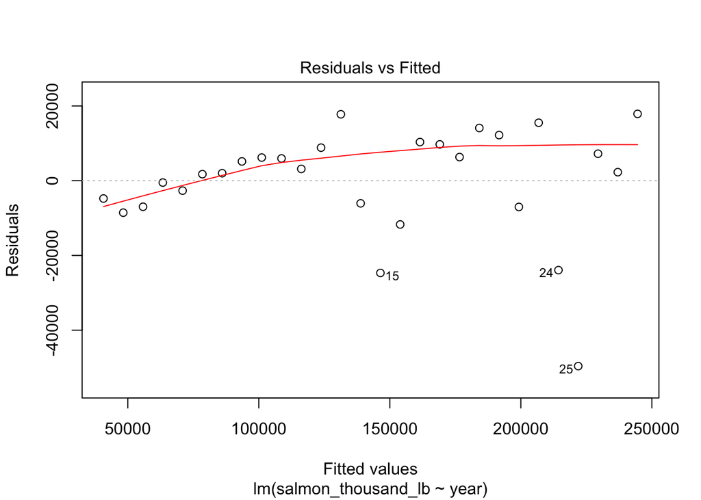

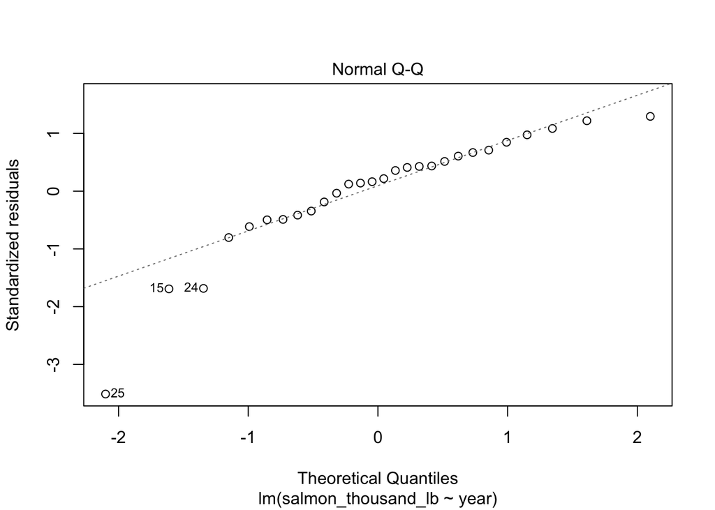

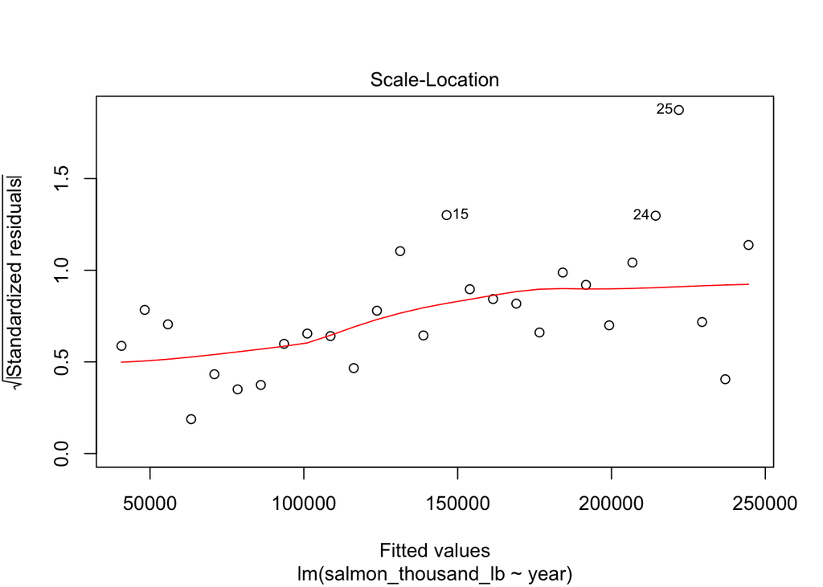

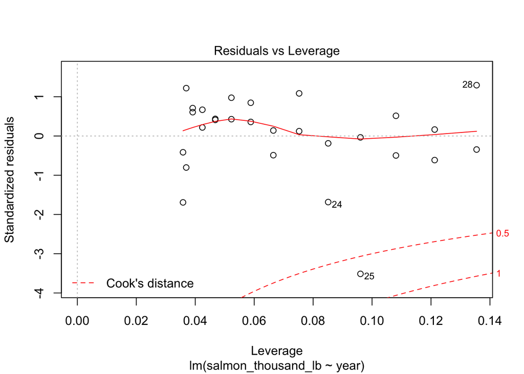

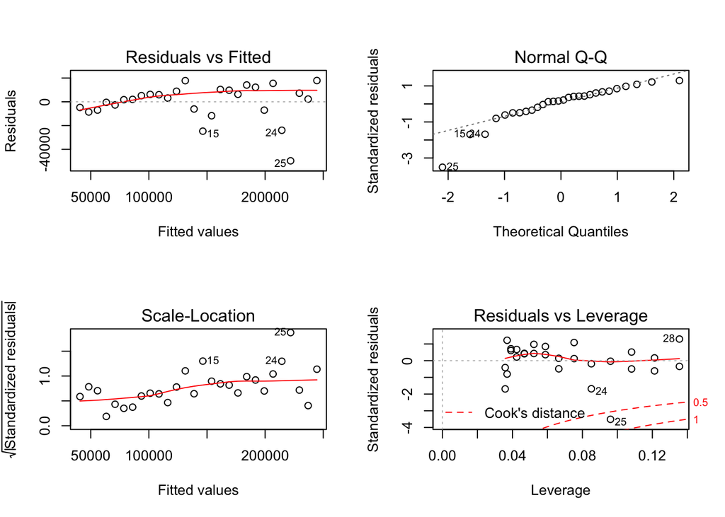

Do residuals appear normally distributed?

Yes, based on the normal Q-Q plot, the residuals do appear normally distributed.

Any concerns about heteroscedasticity or outliers?

I would say that based on the residuals vs fitted plot, it’s showing more heteroscedasticity, and based on the residuals vs leverage plot, there are outliers (24, 25, 28) that may be influencing the data.

```
##
## Call:
## lm(formula = salmon_thousand_lb ~ year, data = salmon)
##
## Residuals:
##    Min     1Q Median     3Q    Max
## -49619  -6284   2722   9063  17884
##
## Coefficients:
##               Estimate Std. Error t value Pr(>|t|)
## (Intercept) -1.498e+07  6.963e+05  -21.52   <2e-16 ***
## year         7.550e+03  3.475e+02   21.72   <2e-16 ***
## ---
## Signif. codes:  0 '***' 0.001 '**' 0.01 '*' 0.05 '.' 0.1 ' ' 1
##
## Residual standard error: 14860 on 26 degrees of freedom
## Multiple R-squared:  0.9478, Adjusted R-squared:  0.9458
## F-statistic: 471.9 on 1 and 26 DF,  p-value: < 2.2e-16
```

Does year significantly predict salmon imports?

The year significantly has an impact in predicting the salmon imports (*p* < 2.2e-16).

What does the R2 value actually mean in words?

94.78% of variance in the dependent variable is predictable from the independent variable.

What proportion of the variance in salmon imports is NOT explained by year?

5.22% of the variance in salmon imports is NOT explained by year.

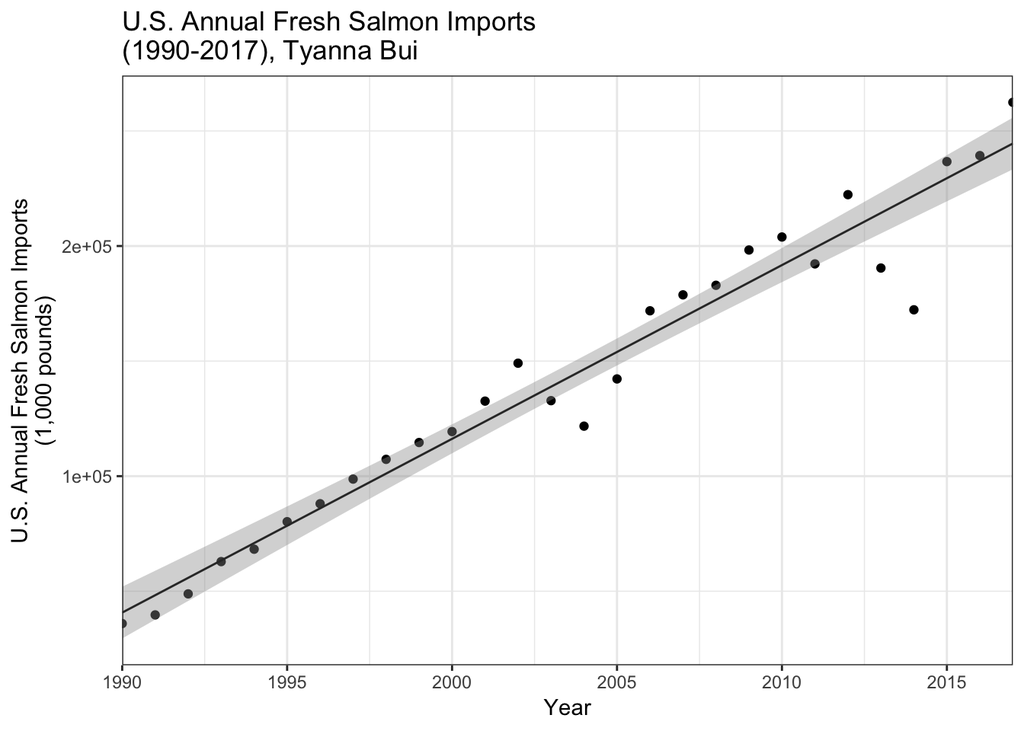

```
##        fit      lwr      upr
## 1 282298.5 267877.4 296719.6
## 2 297397.6 281656.7 313138.5
## 3 327595.9 309166.6 346025.2
```

```
##
##  Pearson's product-moment correlation
##
## data:  salmon$year and salmon$salmon_thousand_lb
## t = 21.723, df = 26, p-value < 2.2e-16
## alternative hypothesis: true correlation is not equal to 0
## 95 percent confidence interval:
##  0.9429434 0.9878307
## sample estimates:
##       cor
## 0.9735387
```

The overall model (Imports(1000 lb) = 7.550e+03(year) - 1.498e+07) explains a significant amount of variance in salmon imports (F(1, 26) = 472, *p* < 0.001, R^2 = 0.95).